As Columbia University students, we want first investigate in Columbia University’s oncumpus crimes between 2010 to 2012, and then compare it with the other 7 colleges in the Ivy League.

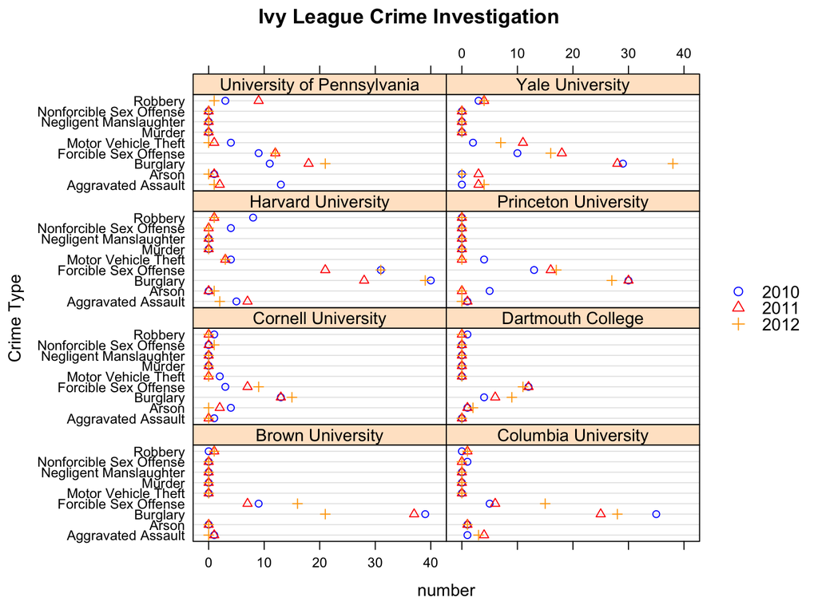

From the plot we can see that Columbia University’s security it not optimistic. Although it has low crime rates on robbery, nonforcible sex offense, negligent manslaughter, murder, and motor vehicle theft, but it has very high forcible sex offense and burglary rates. Moreover, although aggravated assault in Columbia University is rare but it happens every year. For the other 7 colleges in the Ivy League, Yale University, Harvard University, Princeton University and Brown University are also in Columbia University’s predicament, all of them have abnormal high forcible sex offense and bulglary rates.

We can also extract from the plot that all Ivy League colleges except University of Pennsylvania and Yale University maintain low robbery, nonforcible sex offense, negligent manslaughter, murder and motor vehicle theft rates. University of Pennsylvania has high robbery crime rate while motor vehicle theft is common in Yale University. Forcible sex offense and burglary are also common in Cornell University and Dartmouth College even though they are the two safest Ivy League universities.

However, above conclusions can be inaccurate because each university has different numbers of people. Therefore, we want to normalize the crimes on the number of people.

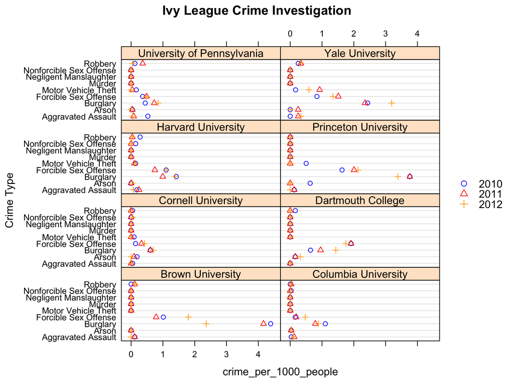

Surprisingly, after the normalizing, Columbia University becomes one of the safest schools in Ivy League. Brown University has the highest number of burglary per 1000 people, while Princeton University has the highest number of forcible sex offense per 1000 people. We suggest each university to take more effective actions to prevent oncumpus forcible sex offense and burglary.

Next we seperate above plot by years in order to detect time pattern.

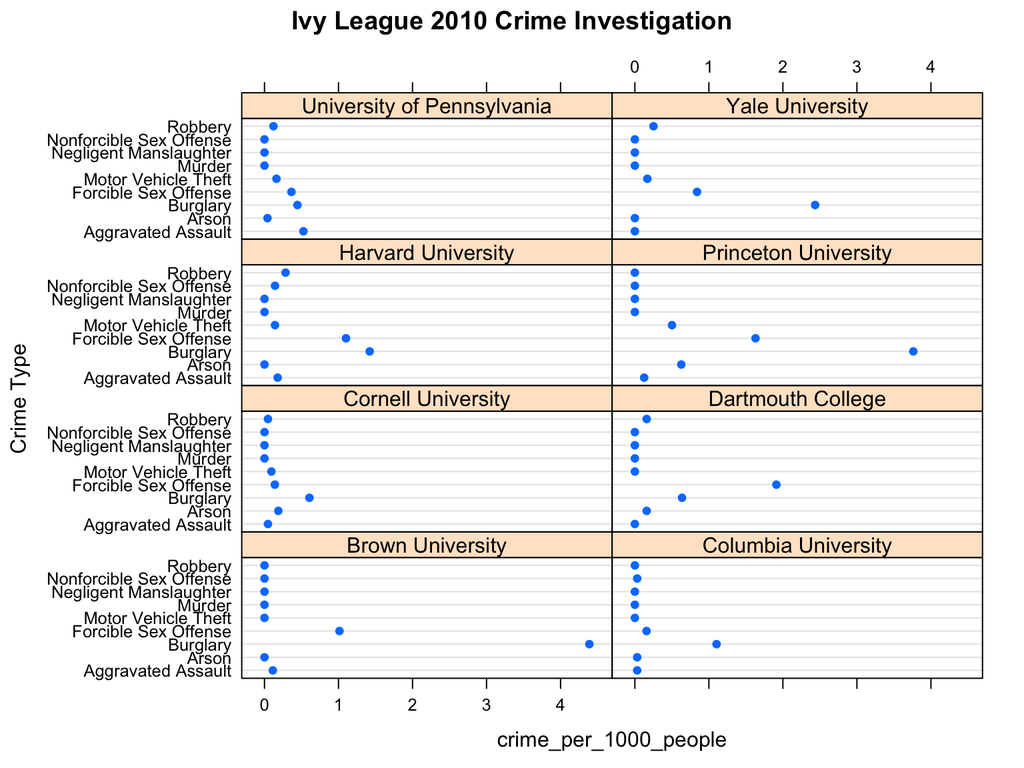

Yale University has fewer forcible sex offense cases in 2010, while Dartmouth College has both fewer burglary and arson cases in 2010.

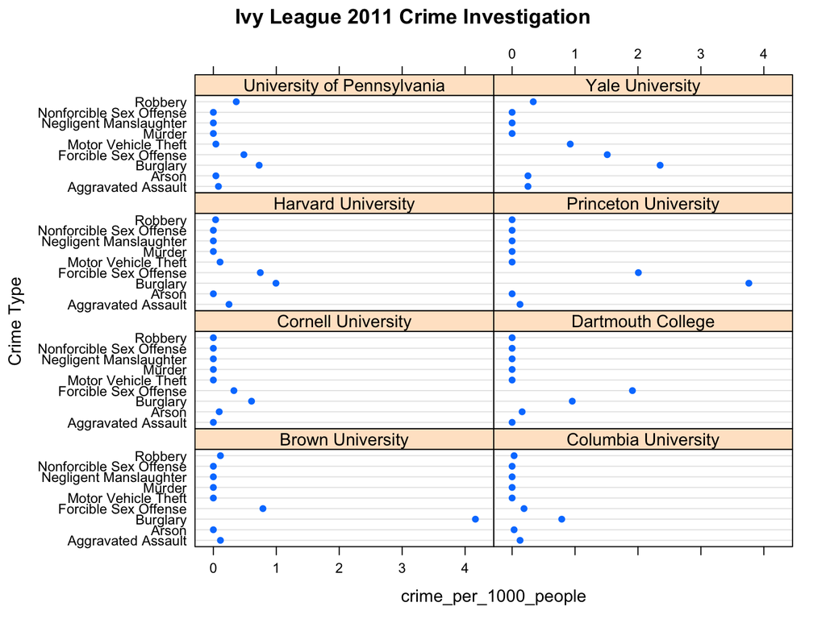

In 2011, motor vehicle theft in Yale University increased dramatically compare to 2010. In comparison, motor vehicle theft in Princeton University decreased to 0 in 2011. But forcible sex offense in Princeton University increased rapidly.

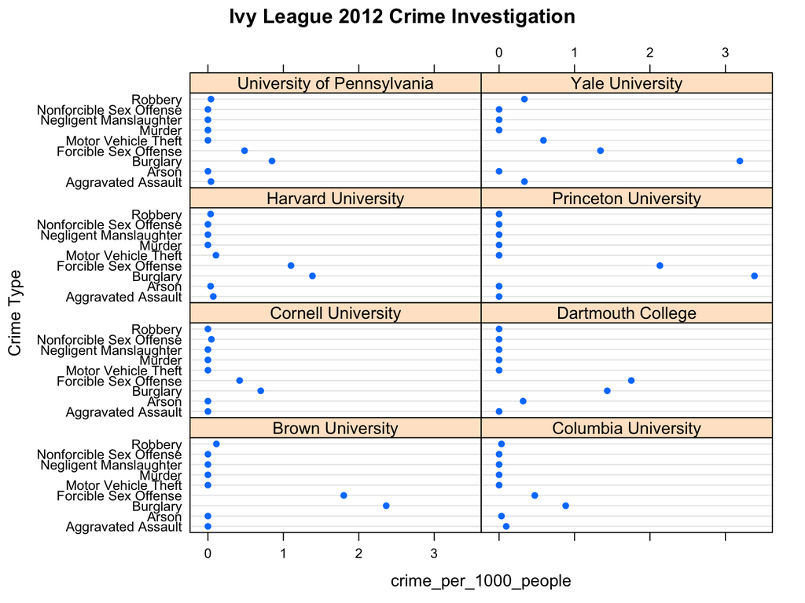

In 2012, burglary in Brown University seems had been effectively controlled, but its forcible sex offense increased dramatically at meantime. Burglary in Yale University also increased rapidly during 2012.

Although number of crimes changed in different years, but we did not detect any clear time pattern in the data.

Because many Columbia students also living off campus, next we want to explore the crime situation of New York City in 2015 from January to September.

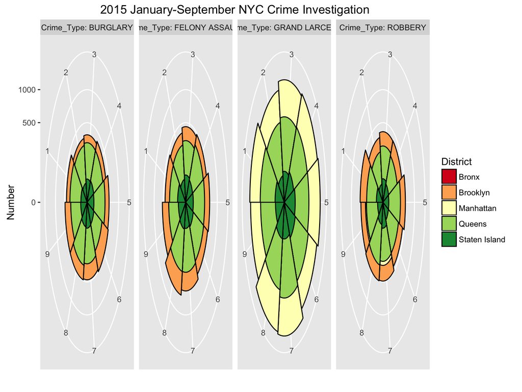

First of all, the graph shows that grand larceny has the largest number among all kinds of crimes, while burglary, felony assault and robbery have similar number.

Secondly, burglary, felony assault and robbery are most serious in Brooklyn, while grand larceny is most serious in Manhattan. Among those 5 districts of New York City, Staten Island is the satest place.

There is no clear time pattern exits in the data. Crime numbers in different months maintain similar level.